# 011 GO enrichment

Clara Jégousse

2022-10-20

## Preliminary settings

### Libraries

```r
library(readr)
library(stringr)
library(dplyr)
library(here)

library(ggplot2)

library(mogo)
library(clusterProfiler)
library(viridis)
```

### Paths

Let’s set the paths to the directory containing the raw data and to the directory to which we will save our results.

```r
raw_data_path = paste(here(), "data", "raw", sep = "/")
result_path = paste(here(), "results", sep = "/")
graphics_path = paste(here(), "graphics", sep = "/")
```

## Cluster 1

### Load data

Read data from csv file and select the transcript identifiers (e.g. `MGG_07200T0`).

```r
cluster1 = read_csv('/Users/jegoussc/GitHub/PD_PRO_1499_06122021_PRM2/analysis/010_kmeans_cluster_ 1 _on_guy11_and_dpmk1.csv') %>%
  dplyr::select(id)
```

Convert transcript identifier to gene identifier (e.g. from `MGG_07200T0` to `MGG_07200`) and **collapse duplicate gene identifiers**: for example, transcript `MGG_07200T0` (gene `MGG_07200`) appears twice in cluster 1 because it correspond to a protein with two phosphorylation sites (`[1-38]-1xMet-loss+Acetyl [N-Term];1xPhospho [S20(91.8)]` and `[1-38]-1xMet-loss+Acetyl [N-Term];1xPhospho [T16(96.9)]`); in this case, we only keep the one instance of the transcript/gene identifier to avoid over-estimating the representation of the GO term(s) associated with this transcript/gene identifier.

```r
clust1 = cluster1 %>% mutate(gene_ids = str_split(id, " ", n = 2, simplify = TRUE)[,1]) %>%
  mutate(gene_ids = str_remove(gene_ids, "T0")) %>%
  dplyr::select(gene_ids) %>%
  unique() # collapse duplicates of the same gene identifier
```

### GO Enrichment

Perform the GO enrichment analysis

```r
enrich1 <- do_enrich(clust1$gene_ids)
```

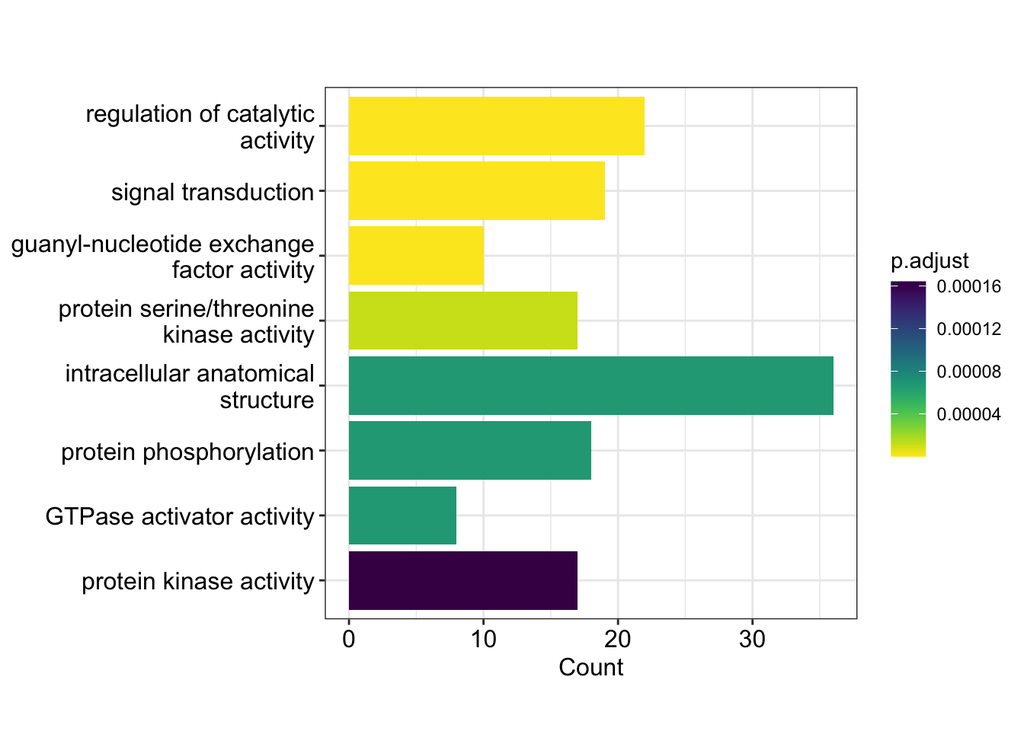

```r
barplot(enrich1) +
  scale_fill_viridis(direction = -1) +
  ggplot2::theme(aspect.ratio = 1)
```

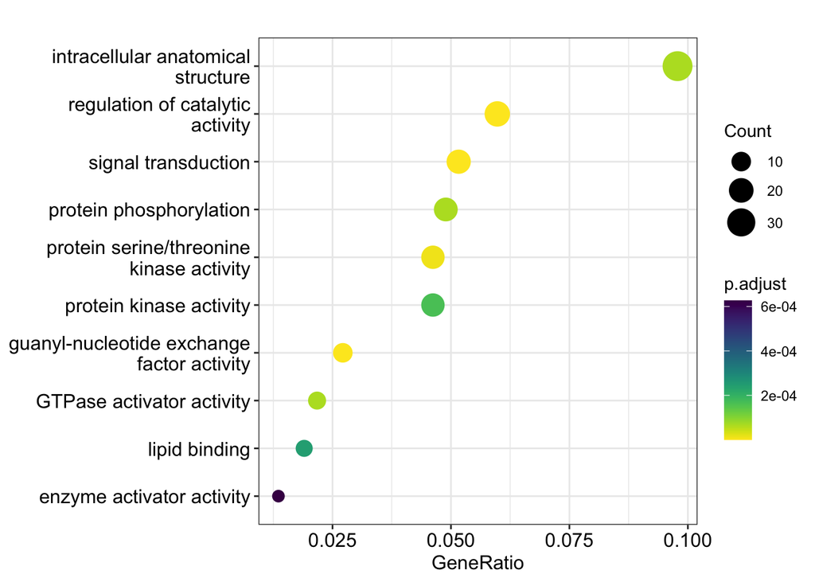

```r
dotplot(enrich1) +
  scale_colour_viridis(direction = -1)
```

### Write results in CSV

```r
enrich1_df = as.data.frame(enrich1) %>%
  select(ID, geneID, Description, GeneRatio, BgRatio, pvalue, p.adjust, qvalue)

csv_filename = paste(result_path, "011_cluster1_go_enrichment.csv", sep = "/")
write_csv(enrich1_df, csv_filename)
```

## Cluster 2

### Load data

Read data from csv file.

```r
cluster2 = read_csv('/Users/jegoussc/GitHub/PD_PRO_1499_06122021_PRM2/analysis/010_kmeans_cluster_ 2 _on_guy11_and_dpmk1.csv') %>%
  dplyr::select(id)
```

Keep only the gene id

```r
clust2 = cluster2 %>% mutate(gene_ids = str_split(id, " ", n = 2, simplify = TRUE)[,1]) %>%
  mutate(gene_ids = str_remove(gene_ids, "T0")) %>%
  dplyr::select(gene_ids) %>%
  unique()
```

### GO Enrichment

```r
enrich2 <- do_enrich(clust2$gene_ids)
```

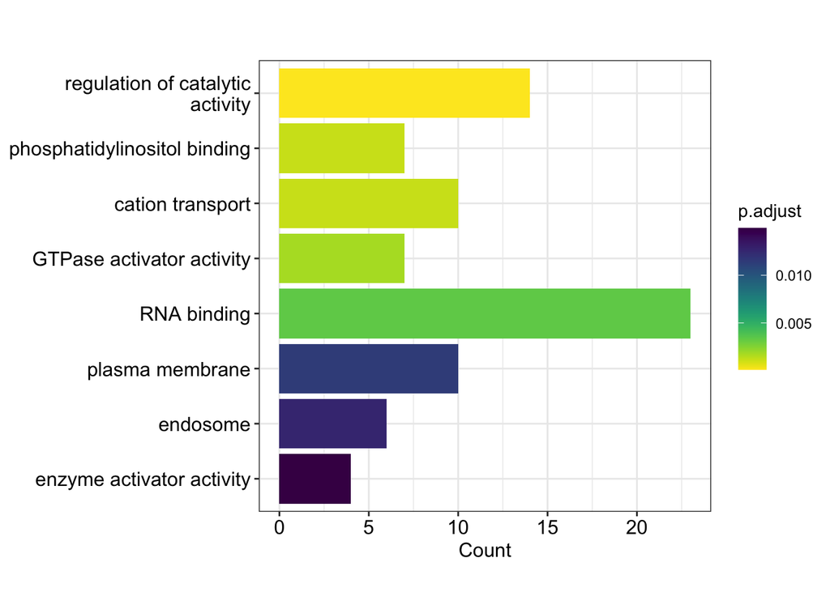

```r
barplot(enrich2) +
  scale_fill_viridis(direction = -1) +
  ggplot2::theme(aspect.ratio = 1)
```

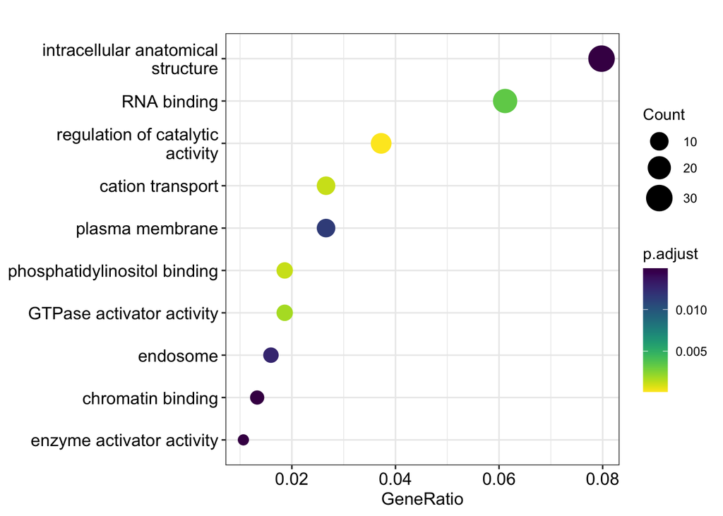

```r
dotplot(enrich2) +
  scale_colour_viridis(direction = -1)
```

### Write results in CSV

```r
enrich2_df = as.data.frame(enrich2) %>%
  select(ID, geneID, Description, GeneRatio, BgRatio, pvalue, p.adjust, qvalue)

csv_filename = paste(result_path, "011_cluster2_go_enrichment.csv", sep = "/")
write_csv(enrich2_df, csv_filename)
```

## Cluster 3

### Load data

Read data from csv file.

```r
cluster3 = read_csv('/Users/jegoussc/GitHub/PD_PRO_1499_06122021_PRM2/analysis/010_kmeans_cluster_ 3 _on_guy11_and_dpmk1.csv') %>% dplyr::select(id)
```

Keep only the gene id

```r
clust3 = cluster3 %>% mutate(gene_ids = str_split(id, " ", n = 2, simplify = TRUE)[,1]) %>%
  mutate(gene_ids = str_remove(gene_ids, "T0")) %>%
  dplyr::select(gene_ids) %>% unique()
```

### GO Enrichment

```r
enrich3 <- do_enrich(clust3$gene_ids)
```

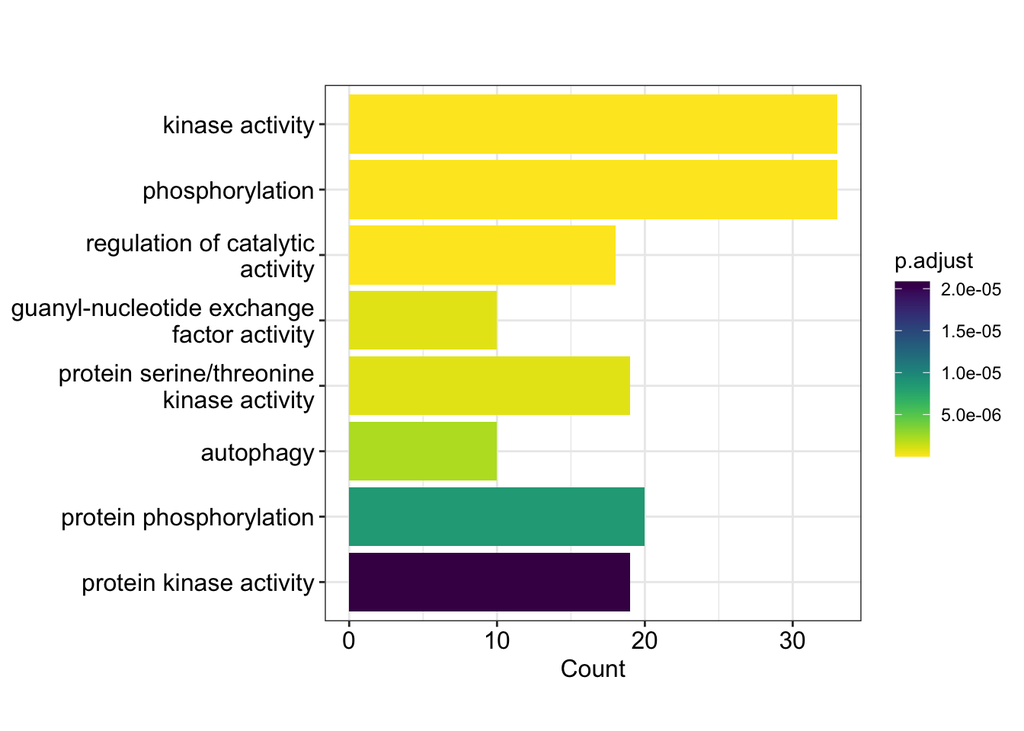

```r
barplot(enrich3) + scale_fill_viridis(direction = -1) + ggplot2::theme(aspect.ratio = 1)
```

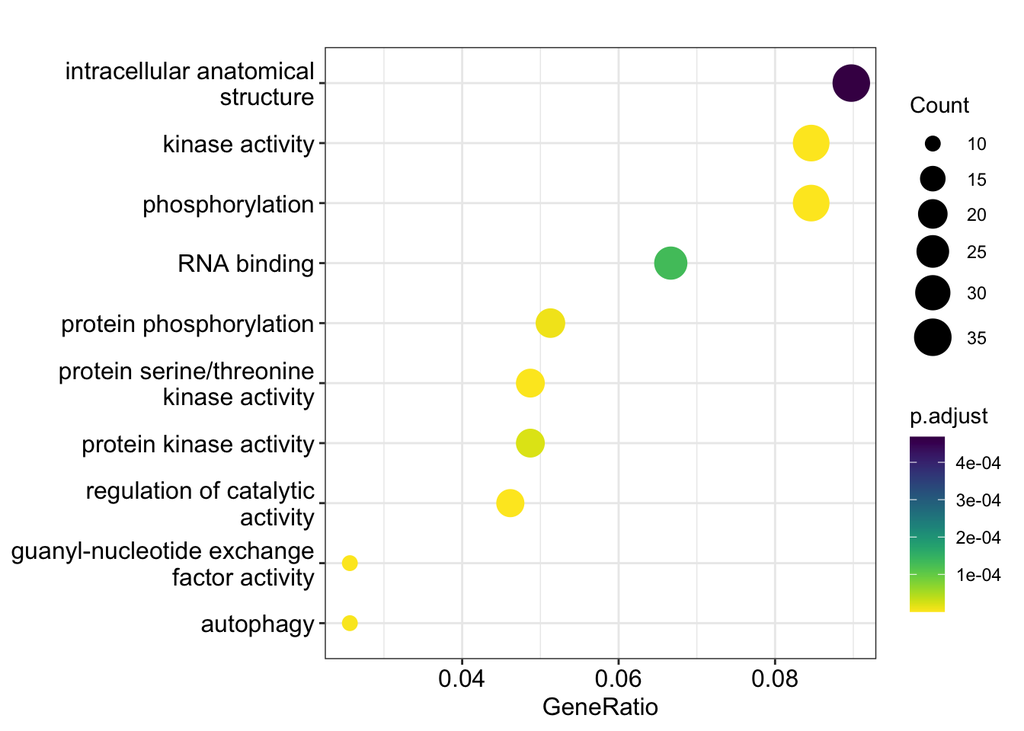

```r
dotplot(enrich3) + scale_colour_viridis(direction = -1)
```

### Write results in CSV

```r
enrich3_df = as.data.frame(enrich3) %>%
  select(ID, geneID, Description, GeneRatio, BgRatio, pvalue, p.adjust, qvalue)

csv_filename = paste(result_path, "011_cluster3_go_enrichment.csv", sep = "/")
write_csv(enrich3_df, csv_filename)
```

## Cluster 4

### Load data

Read data from csv file.

```r
cluster4 = read_csv('/Users/jegoussc/GitHub/PD_PRO_1499_06122021_PRM2/analysis/010_kmeans_cluster_ 4 _on_guy11_and_dpmk1.csv') %>%
  dplyr::select(id)
```

Keep only the gene id

```r
clust4 = cluster4 %>% mutate(gene_ids = str_split(id, " ", n = 2, simplify = TRUE)[,1]) %>%
  mutate(gene_ids = str_remove(gene_ids, "T0")) %>%
  dplyr::select(gene_ids) %>%
  unique()
```

### GO Enrichment

```r
enrich4 <- do_enrich(clust4$gene_ids)
```

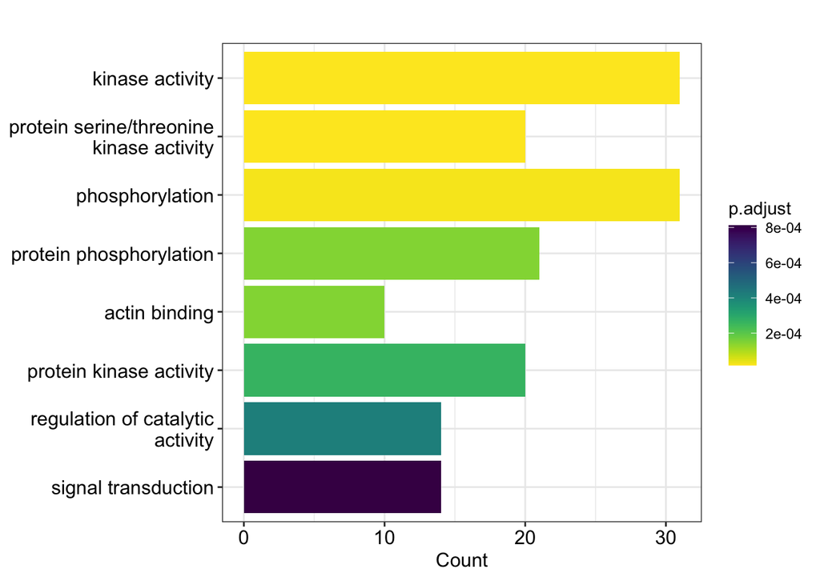

```r
barplot(enrich4) +
  scale_fill_viridis(direction = -1) +
  ggplot2::theme(aspect.ratio = 1)
```

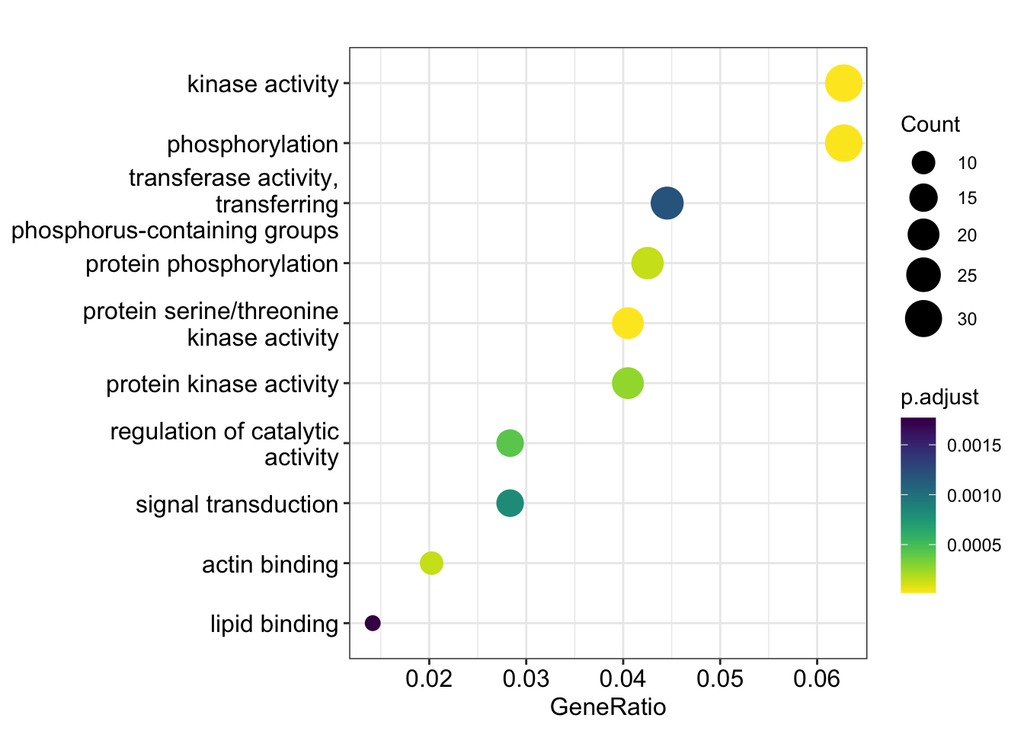

```r
dotplot(enrich4) +
  scale_colour_viridis(direction = -1)
```

### Write results in CSV

```r
enrich4_df = as.data.frame(enrich4) %>%
  select(ID, geneID, Description, GeneRatio, BgRatio, pvalue, p.adjust, qvalue)

csv_filename = paste(result_path, "011_cluster4_go_enrichment.csv", sep = "/")
write_csv(enrich3_df, csv_filename)
```

## Cluster 5

### Load data

Read data from csv file.

```r
cluster5 = read_csv('/Users/jegoussc/GitHub/PD_PRO_1499_06122021_PRM2/analysis/010_kmeans_cluster_ 5 _on_guy11_and_dpmk1.csv') %>%
  dplyr::select(id)
```

Keep only the gene id

```r
clust5 = cluster5 %>% mutate(gene_ids = str_split(id, " ", n = 2, simplify = TRUE)[,1]) %>%
  mutate(gene_ids = str_remove(gene_ids, "T0")) %>%
  dplyr::select(gene_ids) %>%
  unique()
```

### GO Enrichment

```r
enrich5 <- do_enrich(clust5$gene_ids)
```

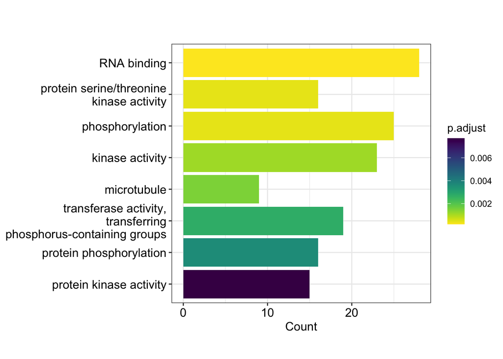

```r
barplot(enrich5) +
  scale_fill_viridis(direction = -1) +
  ggplot2::theme(aspect.ratio = 1)
```

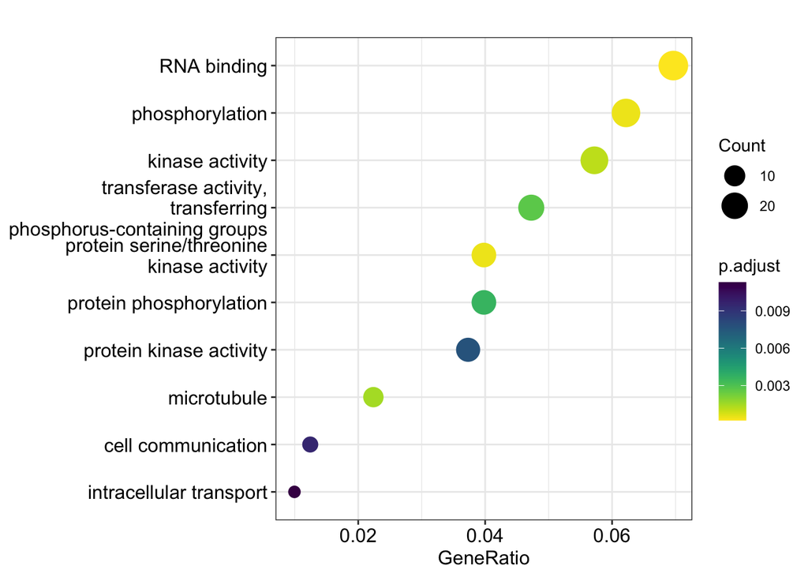

```r
dotplot(enrich5) +
  scale_colour_viridis(direction = -1)
```

### Write results in CSV

```r
enrich5_df = as.data.frame(enrich5) %>%
  select(ID, geneID, Description, GeneRatio, BgRatio, pvalue, p.adjust, qvalue)

csv_filename = paste(result_path, "011_cluster5_go_enrichment.csv", sep = "/")
write_csv(enrich5_df, csv_filename)
```

## Selected protein target

### Load data

Read data from csv file.

```r
data_filename = paste(raw_data_path, "Pmk1 direct targets PRM_101122.xlsx", sep = "/")

targets = readxl::read_xlsx(data_filename) %>%
  dplyr::select(`Phosphorylation position`) %>% unique()
```

Keep only the gene id (for now I remove gi number) Replacement:

gi|145610929|ref|XP_368444.2| MST7 = MGG_00800 gi|39964959|ref|XP_365053.1| MAC1 (S75) = MGG_09898

```r
targets2 = targets %>%
  dplyr::mutate(gene_ids =
      stringr::str_split(`Phosphorylation position`, " ", n = 2, simplify = TRUE)[,1]) %>%
  dplyr::mutate(gene_ids = ifelse(`gene_ids` == 'gi|145610929|ref|XP_368444.2|',
    'MGG_00800', gene_ids)) %>%
  dplyr::mutate(gene_ids = ifelse(`gene_ids` == 'gi|39964959|ref|XP_365053.1|',
    'MGG_09898', gene_ids))
```

In several cases, few selected peptides correspond to the same protein and thus the different lines/rows (peptides) are collapsed so that a single MGG number (gene/protein) is taken into consideration in the GO enrichment analysis resulting in a list of 31 proteins.

```r
gene_ids = targets2 %>%
  dplyr::mutate(gene_ids = stringr::str_split(`Phosphorylation position`, " ", n = 2, simplify = TRUE)[,1]) %>%
  dplyr::filter(str_detect(gene_ids, "^MGG")) %>%
  dplyr::select(gene_ids)  %>%
  unique()
```

### GO Enrichment

```r
enrich_targets <- do_enrich(gene_ids$gene_ids)
```

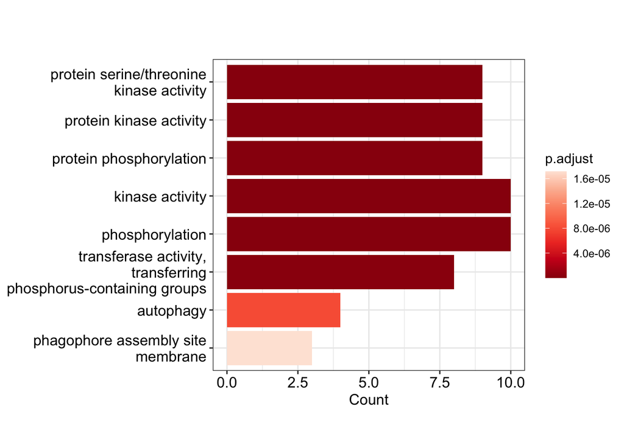

```r
barplot(enrich_targets) +
  #scale_fill_viridis(direction = -1) +
  ggplot2::scale_fill_distiller(type = "seq", direction = -1, palette = 'Reds') +
  ggplot2::theme(aspect.ratio = 1)
```

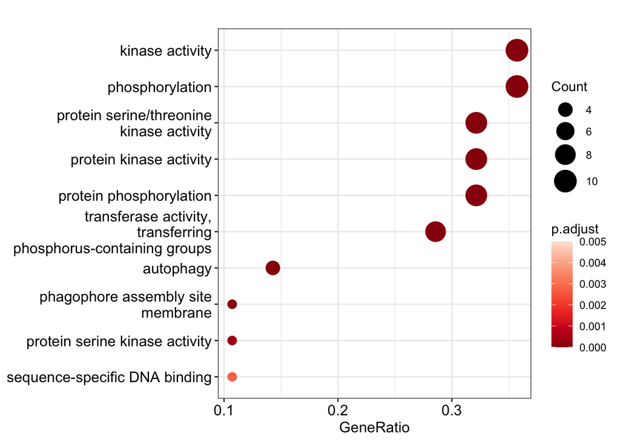

```r
# PRM-GO-dotplot.pdf
dotplot(enrich_targets) +
  ggplot2::scale_colour_distiller(type = "seq", direction = -1, palette = 'Reds', limits = c(0, 0.005))
```

```r
# limits and directions are set so that the more intense the colour is, more smaller/better the p-value is
```

### Write results in CSV

```r
enrich_targets_df = as.data.frame(enrich_targets) %>%
  select(ID, geneID, Description, GeneRatio, BgRatio, pvalue, p.adjust, qvalue)

csv_filename = paste(result_path, "011_targets_go_enrichment.csv", sep = "/")
write_csv(enrich_targets_df, csv_filename)
```

# Summary

February 2023: New request from Neftaly.

Let’s summarise all the go enrichement analysis in a single dot plot.

First, for all the dataframe build previously, we add a column with the cluster number (as categorial variable, not numerical).

```r
enrich1_df$cluster = "1"
enrich2_df$cluster = "2"
enrich3_df$cluster = "3"
enrich4_df$cluster = "4"
enrich5_df$cluster = "5"
```

Now we can bind all these data frames together.

```r
enrichment_summary_df = rbind(enrich1_df, enrich2_df,
  enrich3_df, enrich4_df, enrich5_df)
```

We transform the current gene ratio (50/100) to its numerical value (0.5).

```r
enrichment_summary_df = enrichment_summary_df |> mutate(
  gene.ratio = sapply(strsplit(enrichment_summary_df$GeneRatio, "/"),
    function(x) as.numeric(x[1])/as.numeric(x[2])))
```

We draw th plot

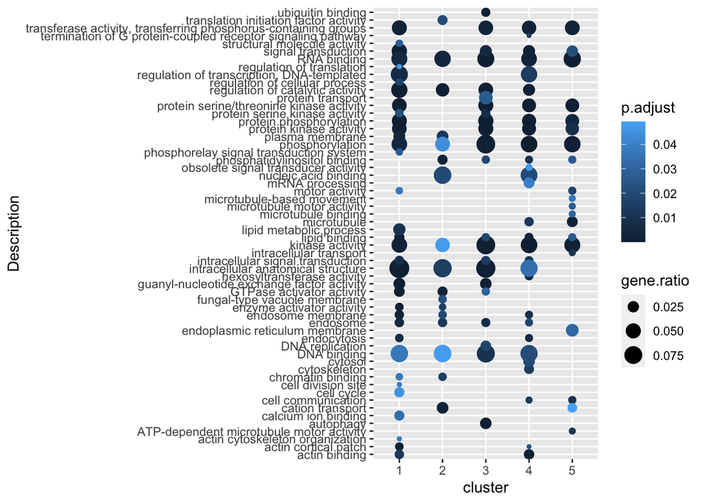

```r
ggplot(enrichment_summary_df,
  aes(x = cluster, y = Description, size = gene.ratio, colour = p.adjust)) +
  geom_point()
```

```r
plot_filename = paste(graphics_path, "011-go-enrichment-summary.pdf", sep = "/")
ggsave(file = plot_filename,
  plot = last_plot(), width = 10, height = 7)
```

Sort out these GO terms!

```r
library(GO.db)
```

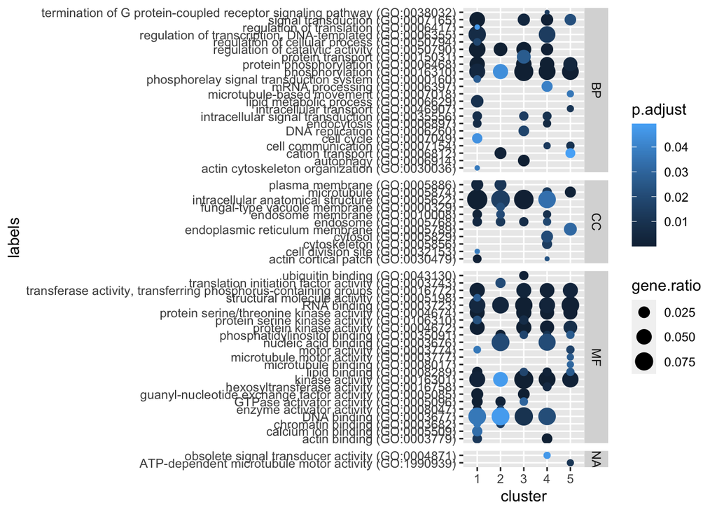

```r
ontology = unlist(Ontology(GOTERM))
enrichment_summary_df$ont = ontology[enrichment_summary_df$ID]

enrichment_summary_df = enrichment_summary_df |> mutate(
  labels = paste0(Description, " (", ID, ")")
  )

ggplot(enrichment_summary_df,
  aes(x = cluster, y = labels, size = gene.ratio, colour = p.adjust)) +
  geom_point() + facet_grid(ont~., scales = "free", space = "free")
```